# AED Proyecto final

Cuál es la canción que pega

Gustavo A. Noriega C., Rubén Rico R., Jairo V. Tamayo R

2023-05-10

# Proyecto final

## Análisis estadístico de datos

### Proyecto: ¿Cuál es la canción que pega?

# Tabla de Contenido

- Introducción
- Objetivos
- 1. Descripción de la pregunta de investigación
- 2. Descripción de los datos
- 3. Presentación del análisis estadístico de los datos

## Introducción

La creación de una canción exitosa es una meta anhelada por la mayoría de los artistas, pero no siempre es fácil lograrla. En este trabajo, se propone realizar un análisis estadístico de las variables obtenidas de las dos plataformas más populares de difusión musical en línea, Spotify y YouTube, con el objetivo de identificar los atributos que influyen en la aceptación del público y el éxito comercial de una nueva canción en el mercado digital. Este estudio permitirá a los artistas enfocarse en los atributos más relevantes y optimizar así su producción, incrementando sus posibilidades de triunfar en la industria musical. Además, se pretende evaluar si es posible predecir la aceptación del público y determinar si el artista ofrece al mercado un producto apetecido.

## Objetivos

1. Establecer cuáles son las variables que afectan favorablemente la aceptación del público mediante la aplicación de métodos estadísticos al conjunto de datos de las 10 mejores canciones de múltiples artistas publicadas en Spotify.
2. Evaluar si existe alguna correlación entre el número de vistas en Youtube, el número de comentarios y el número de “me gusta”, y la frecuencia con la que es sugerido un tema por parte del algoritmo de la aplicación.
3. El objetivo principal de este proyecto es producir una aplicación de los métodos estadísticos multivariantes vistos a lo largo del curso utilizando uno o varios conjuntos de datos.

## 1. Descripción de la pregunta de investigación

Descripción de la pregunta / problema de investigación:

El propósito de esta investigación es realizar un análisis estadístico de las variables obtenidas de dos populares plataformas de streaming de música en línea, Spotify y YouTube, para investigar los factores que influyen en la aceptación de la audiencia y el éxito comercial de nuevas canciones en el mercado digital. La pregunta principal de la investigación es: ¿Cuáles son los atributos clave que contribuyen significativamente a la aceptación por parte de la audiencia y al éxito comercial de las canciones en las plataformas digitales de música?

Los problemas de investigación identificados son los siguientes:

1. Identificar los atributos musicales y no musicales que están asociados con una mayor aceptación de la audiencia en Spotify y YouTube.
2. Determinar si existen diferencias significativas en los atributos preferidos por la audiencia entre ambas plataformas.
3. Evaluar la viabilidad de predecir la aceptación de la audiencia en función de los atributos identificados.
4. Investigar si ofrecer productos musicales con los atributos deseados influye en el éxito comercial de los artistas en la industria musical.

Al realizar un análisis estadístico de los datos obtenidos de Spotify y YouTube, esta investigación pretende proporcionar información valiosa a los artistas y productores, permitiéndoles centrarse en los atributos más relevantes y optimizar la producción de sus canciones, aumentando así sus posibilidades de éxito en la competitiva industria musical. Además, las conclusiones de este estudio pueden tener implicaciones prácticas para la toma de decisiones estratégicas en el ámbito de la promoción y distribución de música en línea.

## 2. Descripción de los datos

Conjunto de Datos En la dirección https://www.kaggle.com/datasets/salvatorerastelli/spotify-and-youtube se presenta una matriz de datos [20.718 , 28], en donde al menos 10 de las 28 variables son numéricas; entre ellas contempla la cantidad de reproducciones en las dos plataformas mencionadas y las manifestaciones positivas.

El conjunto de datos proporcionado en el enlace https://www.kaggle.com/datasets/salvatorerastelli/spotify-and-youtube, contiene una matriz de datos con un tamaño de 20,718 filas y 28 columnas. Esto significa que hay 20,718 observaciones o instancias, y que cada observación tiene asociadas 28 variables diferentes.

Dentro de este conjunto de datos, hay al menos 10 variables que se representan como valores numéricos. Estas variables recogen diversos aspectos relacionados con las canciones, como el número de reproducciones o streams que recibieron en Spotify y YouTube. Además, el conjunto de datos incluye variables que miden manifestaciones positivas o comentarios, que podrían indicar el nivel de aceptación o compromiso del público con las canciones.

### 2.1 Descripción conceptual de los datos.

Con base en el análisis de los datos, las siguientes variables no deben tenerse en cuenta en el modelo de regresión lineal múltiple, debido a que para el modelo de regresión lineal múltiple es fundamental excluir las variables categóricas, los identificadores únicos y las variables relacionadas con la información descriptiva. Estas variables carecen de un carácter cuantitativo directo y no proporcionan información relevante para predecir con exactitud la variable dependiente. Al excluir estas variables del análisis, podemos centrarnos en los predictores significativos que mejorarán la capacidad predictiva y la fiabilidad del modelo.

**X**: Número de índice de la observación en el conjunto de datos. Esta variable sirve como identificador sin significación estadística y no aporta información sustancial para predecir la variable dependiente.

**Artista:** Nombre del artista que interpreta la canción. Como variable categórica, no posee carácter cuantitativo y no debe utilizarse directamente en el modelo de regresión.

**Url_spotify:** URL de Spotify asociada al artista. Esta variable representa una dirección web y carece de carácter cuantitativo. Además, no ofrece información significativa para predecir la variable dependiente.

**Track:** Nombre de la canción. Al igual que la variable “Artista”, es categórica y carece de carácter cuantitativo directo.

**Álbum:** Nombre del álbum al que pertenece la canción. Al tratarse de una variable categórica, no puede incorporarse directamente al modelo de regresión lineal múltiple.

**Tipo_álbum:** Tipo de álbum. Al ser una variable categórica, no posee un carácter cuantitativo directo y no aporta información sustancial para predecir la variable dependiente.

**Uri:** Identificador único de la canción en Spotify. Esta variable, al servir como identificador único, carece de carácter cuantitativo y no aporta información relevante para el modelo de regresión.

**Url_youtube:** URL de YouTube asociada al vídeo de la canción. De forma similar a “Url_spotify”, esta variable representa una dirección web y no posee un carácter cuantitativo directo.

**Title:** Título del vídeo de la canción. Como variable categórica, no posee un carácter cuantitativo directo y no aporta información sustancial para predecir la variable dependiente.

**Canal:** Canal de YouTube asociado al artista. Al ser una variable categórica, no posee un carácter cuantitativo directo y no aporta información relevante para el modelo de regresión.

**Descripción:** Descripción asociada al vídeo de la canción. Al ser una variable textual, carece de carácter cuantitativo directo y no aporta información sustancial para predecir la variable dependiente.

Después de realizar el análisis anterior, se elimina del conjunto de datos aquellas columnas o variables categóricas que no aportan información relevante para el modelo de regresión.

Asimismo, se calcula la relación entre las variables “Views” y “Likes” del conjunto de datos y el resultado se asigna a una nueva columna llamada “views_likes_ratio”, El conjunto de datos resultante, se muestra a continuación, luego de identificar y eliminar los datos faltantes:

| Danceability | Energy | Key | Loudness | Speechiness | Acousticness | Instrumentalness | Liveness |
| --- | --- | --- | --- | --- | --- | --- | --- |
| 0.818 | 0.705 | 6 | -6.679 | 0.1770 | 8.36e-03 | 0.002330 | 0.6130 |
| 0.676 | 0.703 | 8 | -5.815 | 0.0302 | 8.69e-02 | 0.000687 | 0.0463 |
| 0.695 | 0.923 | 1 | -3.930 | 0.0522 | 4.25e-02 | 0.046900 | 0.1160 |
| 0.689 | 0.739 | 2 | -5.810 | 0.0260 | 1.51e-05 | 0.509000 | 0.0640 |
| 0.663 | 0.694 | 10 | -8.627 | 0.1710 | 2.53e-02 | 0.000000 | 0.0698 |
| 0.760 | 0.891 | 11 | -5.852 | 0.0372 | 2.29e-02 | 0.086900 | 0.2980 |

### 2.2 Análisis individual de variables.

La siguiente tabla contiene los estadísticos de cada una de las variables del conjunto de datos a analizar:

|  | Danceability | Energy | Key | Loudness | Speechiness | Acousticness | Instrumentalness | Liveness | Valence | Tempo | Duration_ms | Views | Likes | Comments | Stream | views_likes_ratio |
| --- | --- | --- | --- | --- | --- | --- | --- | --- | --- | --- | --- | --- | --- | --- | --- | --- |
|  | Min. :0.0000 | Min. :0.0000203 | Min. : 0.000 | Min. :-46.251 | Min. :0.00000 | Min. :0.0000011 | Min. :0.0000000 | Min. :0.0145 | Min. :0.000 | Min. : 0.00 | Min. : 30985 | Min. :2.600e+01 | Min. : 0 | Min. : 0 | Min. :6.574e+03 | Min. :0.000000 |
|  | 1st Qu.:0.5190 | 1st Qu.:0.5080000 | 1st Qu.: 2.000 | 1st Qu.: -8.772 | 1st Qu.:0.03570 | 1st Qu.:0.0444000 | 1st Qu.:0.0000000 | 1st Qu.:0.0940 | 1st Qu.:0.339 | 1st Qu.: 96.99 | 1st Qu.: 180240 | 1st Qu.:1.912e+06 | 1st Qu.: 22380 | 1st Qu.: 531 | 1st Qu.:1.781e+07 | 1st Qu.:0.005673 |
|  | Median :0.6390 | Median :0.6660000 | Median : 5.000 | Median : -6.516 | Median :0.05070 | Median :0.1900000 | Median :0.0000023 | Median :0.1250 | Median :0.536 | Median :119.96 | Median : 213253 | Median :1.491e+07 | Median : 127909 | Median : 3343 | Median :4.979e+07 | Median :0.008774 |
|  | Mean :0.6211 | Mean :0.6351700 | Mean : 5.294 | Mean : -7.633 | Mean :0.09539 | Mean :0.2891060 | Mean :0.0552922 | Mean :0.1912 | Mean :0.529 | Mean :120.61 | Mean : 224628 | Mean :9.546e+07 | Mean : 670049 | Mean : 27864 | Mean :1.371e+08 | Mean :0.012210 |
|  | 3rd Qu.:0.7420 | 3rd Qu.:0.7970000 | 3rd Qu.: 8.000 | 3rd Qu.: -4.929 | 3rd Qu.:0.10400 | 3rd Qu.:0.4700000 | 3rd Qu.:0.0004330 | 3rd Qu.:0.2340 | 3rd Qu.:0.725 | 3rd Qu.:139.95 | 3rd Qu.: 251920 | 3rd Qu.:7.153e+07 | 3rd Qu.: 526640 | 3rd Qu.: 14493 | 3rd Qu.:1.391e+08 | 3rd Qu.:0.014985 |
|  | Max. :0.9750 | Max. :1.0000000 | Max. :11.000 | Max. : 0.920 | Max. :0.96400 | Max. :0.9960000 | Max. :1.0000000 | Max. :1.0000 | Max. :0.993 | Max. :243.37 | Max. :4676058 | Max. :8.080e+09 | Max. :50788652 | Max. :16083138 | Max. :3.387e+09 | Max. :0.249204 |

A continuación se presentan los histogramas de cada una de las variables:

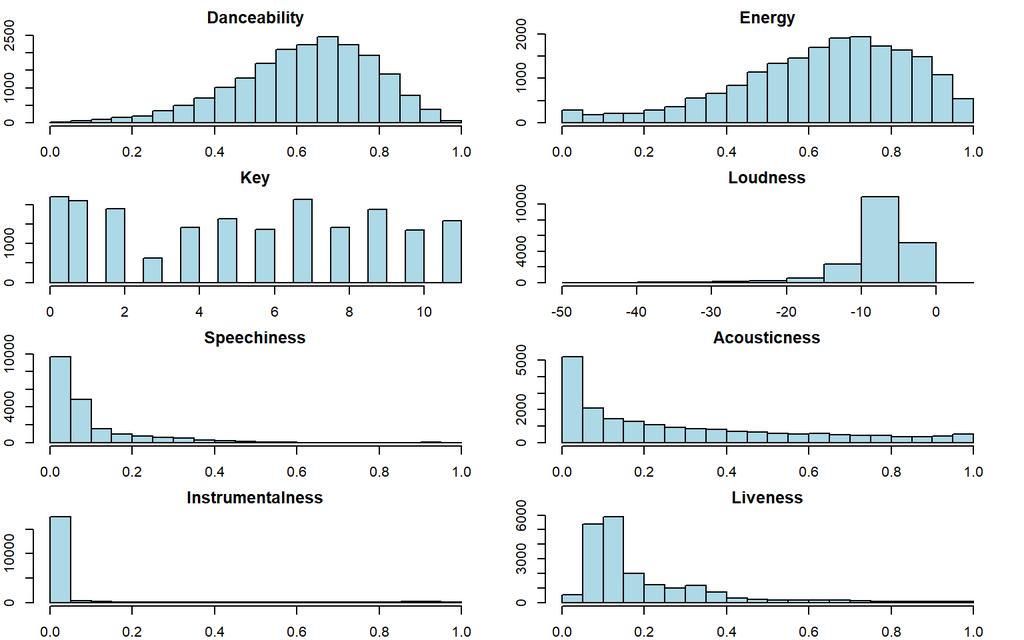

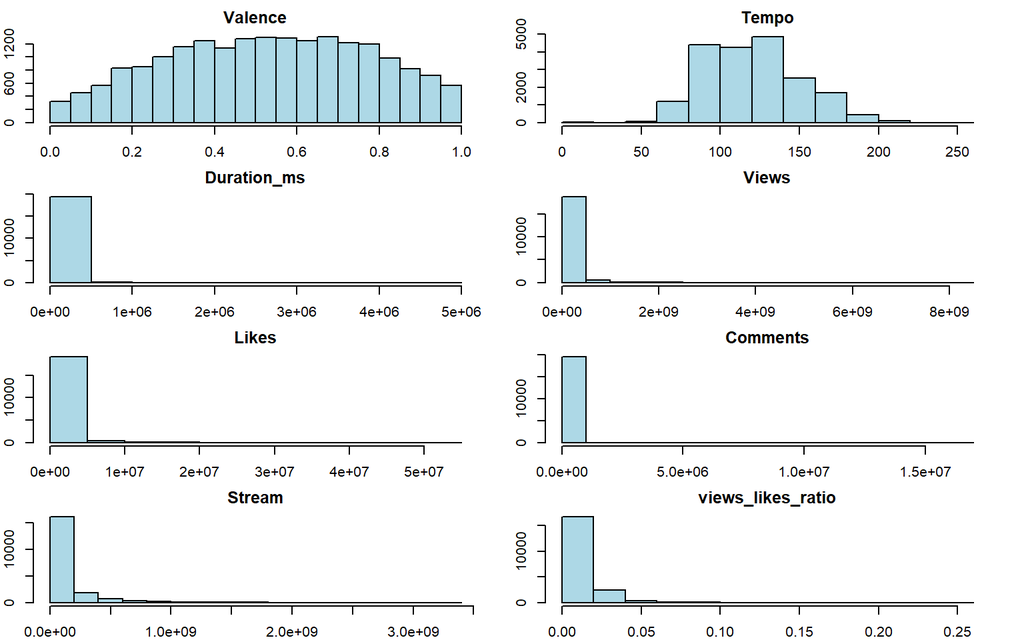

### 2.3 Análisis conjunto de variables (correlaciones)

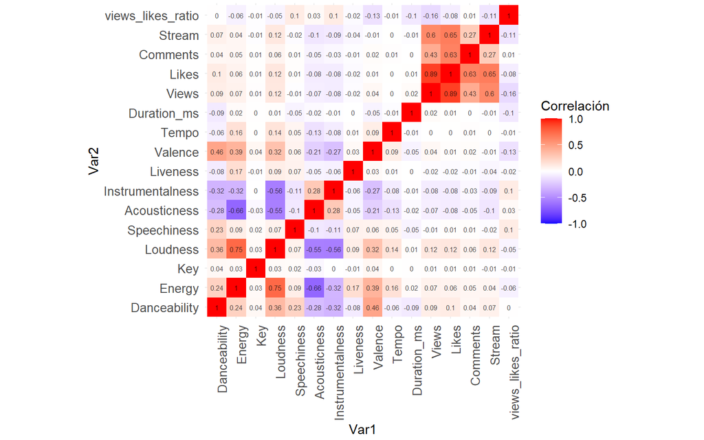

## 3. Presentación del análisis estadístico de los datos

### 3.1 Métodos

Resumen del modelo de regresión lineal múltiple

|  | Coefficients | Estimate | Std..Error | t.value | Pr…t.. | Multiple.R.squared | Adjusted.R.squared |
| --- | --- | --- | --- | --- | --- | --- | --- |
| (Intercept) | (Intercept) | 0.0171022 | 0.0008622 | 19.8350900 | 0.0000000 | 0.0621171 | 0.061493 |
| Danceability | Danceability | 0.0045413 | 0.0005960 | 7.6193973 | 0.0000000 | 0.0621171 | 0.061493 |
| Energy | Energy | -0.0022963 | 0.0006756 | -3.3989479 | 0.0006778 | 0.0621171 | 0.061493 |
| Key | Key | -0.0000325 | 0.0000217 | -1.4959711 | 0.1346773 | 0.0621171 | 0.061493 |
| Loudness | Loudness | 0.0001762 | 0.0000303 | 5.8199188 | 0.0000000 | 0.0621171 | 0.061493 |
| Speechiness | Speechiness | 0.0103350 | 0.0007614 | 13.5733935 | 0.0000000 | 0.0621171 | 0.061493 |
| Acousticness | Acousticness | -0.0002220 | 0.0003764 | -0.5897158 | 0.5553880 | 0.0621171 | 0.061493 |
| Instrumentalness | Instrumentalness | 0.0063858 | 0.0005057 | 12.6276144 | 0.0000000 | 0.0621171 | 0.061493 |
| Liveness | Liveness | -0.0009322 | 0.0004853 | -1.9210563 | 0.0547392 | 0.0621171 | 0.061493 |
| Valence | Valence | -0.0067004 | 0.0003913 | -17.1222822 | 0.0000000 | 0.0621171 | 0.061493 |
| Tempo | Tempo | 0.0000024 | 0.0000027 | 0.9033491 | 0.3663518 | 0.0621171 | 0.061493 |
| Duration_ms | Duration_ms | 0.0000000 | 0.0000000 | -13.5021142 | 0.0000000 | 0.0621171 | 0.061493 |
| Comments | Comments | 0.0000000 | 0.0000000 | 5.5543674 | 0.0000000 | 0.0621171 | 0.061493 |
| Stream | Stream | 0.0000000 | 0.0000000 | -17.1571027 | 0.0000000 | 0.0621171 | 0.061493 |

Con el objetivo de mejorar el ajuste del modelo de regresión lineal múltiple, consideraremos la eliminación de las variables que tienen un valor p alto (p > 0.05), ya que indican una falta de significancia estadística en relación a la variable dependiente (views_likes_ratio). En base a los resultados proporcionados, las variables a retirar del modelo son:

- **Key:** La variable Key tiene un coeficiente estimado de -3.249e-05 y un valor p de 0.134677. Esto indica que la tonalidad de la canción (clave musical) no es estadísticamente significativa para predecir la variable dependiente. Por lo tanto, podríamos considerar eliminarla del modelo.
- **Acousticness:** La variable Acousticness tiene un coeficiente estimado de -2.220e-04 y un valor p de 0.555388. Esto indica que la característica acústica de la canción no tiene una relación estadísticamente significativa con la variable dependiente.
- **Tempo:** La variable Tempo tiene un coeficiente estimado de 2.440e-06 y un valor p de 0.366352. Esto indica que el tempo de la canción no es estadísticamente significativo para predecir la variable dependiente.

Al retirar estas variables, el modelo podría tener un mayor ajuste y mayor capacidad para explicar la variabilidad en la variable dependiente (views_likes_ratio).

Resumen del modelo de regresión lineal múltiple

|  | Coefficients | Estimate | Std..Error | t.value | Pr…t.. | Multiple.R.squared | Adjusted.R.squared |
| --- | --- | --- | --- | --- | --- | --- | --- |
| (Intercept) | (Intercept) | 0.0169400 | 0.0006765 | 25.038843 | 0.0000000 | 0.0617622 | 0.0613301 |
| Danceability | Danceability | 0.0046480 | 0.0005728 | 8.114440 | 0.0000000 | 0.0617622 | 0.0613301 |
| Energy | Energy | -0.0022625 | 0.0005853 | -3.865520 | 0.0001112 | 0.0617622 | 0.0613301 |
| Loudness | Loudness | 0.0001804 | 0.0000302 | 5.978887 | 0.0000000 | 0.0617622 | 0.0613301 |
| Speechiness | Speechiness | 0.0102597 | 0.0007571 | 13.550550 | 0.0000000 | 0.0617622 | 0.0613301 |
| Instrumentalness | Instrumentalness | 0.0063956 | 0.0005042 | 12.685829 | 0.0000000 | 0.0617622 | 0.0613301 |
| Valence | Valence | -0.0067265 | 0.0003842 | -17.507242 | 0.0000000 | 0.0617622 | 0.0613301 |
| Duration_ms | Duration_ms | 0.0000000 | 0.0000000 | -13.499428 | 0.0000000 | 0.0617622 | 0.0613301 |
| Comments | Comments | 0.0000000 | 0.0000000 | 5.560683 | 0.0000000 | 0.0617622 | 0.0613301 |
| Stream | Stream | 0.0000000 | 0.0000000 | -17.091216 | 0.0000000 | 0.0617622 | 0.0613301 |

Al comparar los dos modelos, podemos observar las siguientes diferencias:

1. **Predictores adicionales**: El primer modelo incluye el predictor “Key”, “Acousticness”, “Liveness” y “Tempo”, que no están presentes en el segundo modelo.
2. **Estadísticas de ajuste:** El primer modelo de regresión lineal, tiene un R cuadrado ajustado ligeramente mayor (0.06149) en comparación con el segundo modelo (0.06133), lo que sugiere un ajuste ligeramente mejor en términos de explicación de la variabilidad en la variable dependiente. Sin embargo, la diferencia es mínima y ambos modelos tienen un ajuste deficiente en general.

En resumen, el primer modelo incluye cuatro predictores adicionales (“Key”, “Acousticness”, “Liveness” y “Tempo”), pero estos no son significativos en la explicación de la variabilidad en la variable dependiente. Por lo tanto, en términos de rendimiento y calidad de ajuste, el segundo modelo que solo incluye los predictores “Danceability, Energy, Loudness, Speechiness, Instrumentalness, Valence, Duration_ms, Comments, Stream” es igualmente válido y puede ser preferible debido a su simplicidad y mayor significancia estadística de los coeficientes.